# Self-Driving Car Engineer Nanodegree

## Project: Build a Traffic Sign Recognition Classifier

In this notebook, a template is provided for you to implement your functionality in stages which is required to successfully complete this project. If additional code is required that cannot be included in the notebook, be sure that the Python code is successfully imported and included in your submission, if necessary. Sections that begin with **'Implementation'** in the header indicate where you should begin your implementation for your project. Note that some sections of implementation are optional, and will be marked with **'Optional'** in the header.

In addition to implementing code, there will be questions that you must answer which relate to the project and your implementation. Each section where you will answer a question is preceded by a **'Question'** header. Carefully read each question and provide thorough answers in the following text boxes that begin with **'Answer:'**. Your project submission will be evaluated based on your answers to each of the questions and the implementation you provide.

> **Note:** Code and Markdown cells can be executed using the **Shift + Enter** keyboard shortcut. In addition, Markdown cells can be edited by typically double-clicking the cell to enter edit mode.

## Step 0: Load The Data

```python
# Load pickled data
import pickle

# TODO: Fill this in based on where you saved the training and testing data

training_file = '.\\data\\train.p'
testing_file = '.\\data\\test.p'

with open(training_file, mode='rb') as f:
    train = pickle.load(f)
with open(testing_file, mode='rb') as f:
    test = pickle.load(f)

#mp X_train, y_train = train['features'], train['labels']
#mp X_test, y_test = test['features'], test['labels']
```

## Step 1: Dataset Summary & Exploration

The pickled data is a dictionary with 4 key/value pairs:

- `'features'` is a 4D array containing raw pixel data of the traffic sign images, (num examples, width, height, channels).
- `'labels'` is a 2D array containing the label/class id of the traffic sign. The file `signnames.csv` contains id -> name mappings for each id.
- `'sizes'` is a list containing tuples, (width, height) representing the the original width and height the image.
- `'coords'` is a list containing tuples, (x1, y1, x2, y2) representing coordinates of a bounding box around the sign in the image. **THESE COORDINATES ASSUME THE ORIGINAL IMAGE. THE PICKLED DATA CONTAINS RESIZED VERSIONS (32 by 32) OF THESE IMAGES**

Complete the basic data summary below.

```python
### Replace each question mark with the appropriate value.
import numpy as np


# TODO: Number of training examples
n_train = len(train['features']) #ok
# TODO: Number of testing examples.
n_test = len(test['features']) #ok

# TODO: What's the shape of an traffic sign image?
image_shape_train = train['sizes'][0] # unclear what to do here in detail. The shape of the first image is returned
image_shape_train_features = train['features'][0].shape # unclear what to do here in detail. The shape of the first image is returned

# TODO: How many unique classes/labels there are in the dataset.
n_classes_train = len(np.unique(train['labels'])) #ok
n_classes_test = len(np.unique(test['labels'])) #ok

print("Number of training examples =", n_train)
print("Number of testing examples =", n_test)
print("Image data shape (train object sizes 0) =", image_shape_train)
print("Image data shape (train object features 0) =", image_shape_train_features)
print(np.unique(train['labels']))
print("Number of training classes =", n_classes_train)
print(np.unique(test['labels']))
print("Number of testing classes =", n_classes_test)
```

```
Number of training examples = 39209
Number of testing examples = 12630
Image data shape (train object sizes 0) = [29 30]
Image data shape (train object features 0) = (32, 32, 3)
[ 0  1  2  3  4  5  6  7  8  9 10 11 12 13 14 15 16 17 18 19 20 21 22 23 24
 25 26 27 28 29 30 31 32 33 34 35 36 37 38 39 40 41 42]
Number of training classes = 43
[ 0  1  2  3  4  5  6  7  8  9 10 11 12 13 14 15 16 17 18 19 20 21 22 23 24
 25 26 27 28 29 30 31 32 33 34 35 36 37 38 39 40 41 42]
Number of testing classes = 43
```

Visualize the German Traffic Signs Dataset using the pickled file(s). This is open ended, suggestions include: plotting traffic sign images, plotting the count of each sign, etc.

The [Matplotlib](http://matplotlib.org/) [examples](http://matplotlib.org/examples/index.html) and [gallery](http://matplotlib.org/gallery.html) pages are a great resource for doing visualizations in Python.

**NOTE:** It's recommended you start with something simple first. If you wish to do more, come back to it after you've completed the rest of the sections.

```
1
(32, 32, 3)
```

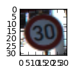

```python
import random
import numpy as np
import matplotlib.pyplot as plt
%matplotlib inline

index = random.randint(0, len(test['features']))
image = test['features'][index]

plt.figure(figsize=(1,1))
#plt.imshow(image, cmap="gray")
plt.imshow(image)
print(test['labels'][index])
print(image.shape)
```

The following code block contains some "playing code" to understand the input data better. The project does not need this code block.

```python
### some test functions to understand the input data better

i=50
print(test['labels'][i])
print(type(test['labels'][i]))
print(test['sizes'][i])
print(test['coords'][i])
print("x-extension: ", (train['coords'][i][2]-train['coords'][i][0]) / train['sizes'][i][0])
print("y-extension: ", (train['coords'][i][3]-train['coords'][i][1]) / train['sizes'][i][1])

print(len(test['sizes']))
print(len(test['features']))
print(len(train['sizes']))
print(len(train['features']))
print(train['sizes'][i])
print(test['features'][3].shape)
```

```
25
<class 'numpy.uint8'>
[27 27]
[ 5  5 22 22]
x-extension:  0.744186
y-extension:  0.767442
12630
12630
39209
39209
[43 43]
(32, 32, 3)
```

## Step 2: Design and Test a Model Architecture

Design and implement a deep learning model that learns to recognize traffic signs. Train and test your model on the [German Traffic Sign Dataset](http://benchmark.ini.rub.de/?section=gtsrb&subsection=dataset).

There are various aspects to consider when thinking about this problem:

- Neural network architecture
- Play around preprocessing techniques (normalization, rgb to grayscale, etc)
- Number of examples per label (some have more than others).
- Generate fake data.

Here is an example of a [published baseline model on this problem](http://yann.lecun.com/exdb/publis/pdf/sermanet-ijcnn-11.pdf). It's not required to be familiar with the approach used in the paper but, it's good practice to try to read papers like these.

**NOTE:** The LeNet-5 implementation shown in the classroom at the end of the CNN lesson is a solid starting point. You'll have to change the number of classes and possibly the preprocessing, but aside from that it's plug and play!

### Implementation

Use the code cell (or multiple code cells, if necessary) to implement the first step of your project. Once you have completed your implementation and are satisfied with the results, be sure to thoroughly answer the questions that follow.

```
17
```

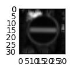

```python
# In this code block the training images will be transformed into
# gray-scale images. Each image can later on be represented as a 32x32
# feature vector
# Input: train['features']
# Output: gray_train_features
# Author: Martin Pfeifle

import random
import matplotlib.pyplot as plt
import matplotlib.image as mpimg
import numpy as np
import cv2
%matplotlib inline

def grayscale(img): # copy from lane detection program
    return cv2.cvtColor(img, cv2.COLOR_BGR2GRAY)

gray_train_features  = np.zeros((len(train['features']),32,32))
for i in range(len(train['features'])):
    gray_train_features[i] = grayscale (train['features'][i])

#Test - Depict one gray training image
index = random.randint(0, len(gray_train_features))
image = gray_train_features[index]

plt.figure(figsize=(1,1))
plt.imshow(image, cmap="gray")
print(train['labels'][index])
```

```
11
```

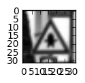

```python
# In this code block the testing images will be transformed into
# gray-scale images of size 32x32. Each image can later on be represented as a 32x32
# feature vector. Both normalization and grayscale is done for the test images
# in this function.
# Input: test['features']
# Output: gray_test_features
# Author: Martin Pfeifle

import random
import matplotlib.pyplot as plt
import matplotlib.image as mpimg
import numpy as np
import cv2
%matplotlib inline

def grayscale(img): # copy from lane detection program
    return cv2.cvtColor(img, cv2.COLOR_BGR2GRAY)

gray_test_features  = np.zeros((len(test['features']),32,32))
for i in range(len(test['features'])):
    gray_test_features[i] = grayscale (test['features'][i])

#Test - Depict one gray test image
index = random.randint(0, len(gray_test_features))
image = gray_test_features[index]

plt.figure(figsize=(1,1))
plt.imshow(image, cmap="gray")
print(test['labels'][index])
```

The following code block creates

- X_train
- y_train
- X_Validation
- y_valdiation
- X_test
- y_test

The idea is that X_train and X_Validation contain data in a 2-dimensional matrix (number of train images, 1024). So each image is represented as a 1024 dimensional feature vector. y_train and y_validation contain the corresponding class values.

X_test and y_test have the same format as the training and validation data. These test data are not used during training.

```python
from sklearn.utils import shuffle

X_train = np.empty([len(gray_train_features),1024])
for i in range(len(X_train)):
    X_train[i]=np.reshape(gray_train_features[i],1024)
y_train = train['labels']

X_validation, y_validation = X_train, y_train

X_test = np.empty([len(gray_test_features),1024])
for i in range(len(X_test)):
    X_test[i]=np.reshape(gray_test_features[i],1024)
y_test = test['labels']

X_train, y_train = shuffle(X_train, y_train)
```

```python
import tensorflow as tf

EPOCHS = 10
BATCH_SIZE = 50
```

The parameter *x* for LeNet is a 1024-dimensional feature vector which is first transformed into a 32x32 image

```python
from tensorflow.contrib.layers import flatten

def LeNet(x):
    # Reshape from 2D to 4D. This prepares the data for
    # convolutional and pooling layers.
    x = tf.reshape(x, (-1, 32, 32, 1))
    # Pad 0s to 32x32. Centers the digit further.
    # Add 2 rows/columns on each side for height and width dimensions.
    # mp: was commented out. strangely enough it was working with padding although the  input is already 32x32
    # x = tf.pad(x, [[0, 0], [2, 2], [2, 2], [0, 0]], mode="CONSTANT")

    # Hyperparameters
    mu = 0
    sigma = 0.1

    # SOLUTION: Convolution Layer 1. Input = 32x32x1. Output = 28x28x6.
    conv1_W = tf.Variable(tf.truncated_normal(shape=(5, 5, 1, 6), mean = mu, stddev = sigma))
    conv1_b = tf.Variable(tf.zeros(6))
    conv1   = tf.nn.conv2d(x, conv1_W, strides=[1, 1, 1, 1], padding='VALID') + conv1_b

    # SOLUTION: Activation 1.
    conv1 = tf.nn.relu(conv1)

    # SOLUTION: Pooling Layer 1. Input = 28x28x6. Output = 14x14x6.
    conv1 = tf.nn.max_pool(conv1, ksize=[1, 2, 2, 1], strides=[1, 2, 2, 1], padding='VALID')

    # SOLUTION: Convolution Layer 2. Output = 10x10x16.
    conv2_W = tf.Variable(tf.truncated_normal(shape=(5, 5, 6, 16), mean = mu, stddev = sigma))
    conv2_b = tf.Variable(tf.zeros(16))
    conv2   = tf.nn.conv2d(conv1, conv2_W, strides=[1, 1, 1, 1], padding='VALID') + conv2_b

    # SOLUTION: Activation 2.
    conv2 = tf.nn.relu(conv2)

    # SOLUTION: Pooling Layer 2. Input = 10x10x16. Output = 5x5x16.
    conv2 = tf.nn.max_pool(conv2, ksize=[1, 2, 2, 1], strides=[1, 2, 2, 1], padding='VALID')

    # SOLUTION: Flatten Layer.
    fc1 = flatten(conv2)
    fc1_shape = (fc1.get_shape().as_list()[-1], 120)

    # SOLUTION: Fully Connected Layer 1. Input = 5x5x16. Output = 120.
    fc1_W     = tf.Variable(tf.truncated_normal(shape=(fc1_shape), mean = mu, stddev = sigma))
    fc1_b     = tf.Variable(tf.zeros(120))
    fc1       = tf.matmul(fc1, fc1_W) + fc1_b

    # SOLUTION: Activation 3.
    fc1 = tf.nn.relu(fc1)

    # SOLUTION: Fully Connected Layer 2. Input = 120. Output = 43.
    fc2_W  = tf.Variable(tf.truncated_normal(shape=(120, 43), mean = mu, stddev = sigma))
    fc2_b  = tf.Variable(tf.zeros(43))
    logits = tf.matmul(fc1, fc2_W) + fc2_b
    return logits
```

```python
def evaluate(X_data, y_data):
    num_examples = len(X_data)
    total_accuracy, total_loss = 0, 0
    sess = tf.get_default_session()
    for offset in range(0, num_examples, BATCH_SIZE):
        batch_x, batch_y = X_data[offset:offset+BATCH_SIZE], y_data[offset:offset+BATCH_SIZE]
        loss, accuracy =  sess.run([loss_operation, accuracy_operation], feed_dict={x: batch_x, y: batch_y})
        total_accuracy += (accuracy * batch_x.shape[0])
        total_loss     += (loss * batch_x.shape[0])
    return total_loss / num_examples, total_accuracy / num_examples
```

```python
x = tf.placeholder(tf.float32, (None, 1024))
y = tf.placeholder(tf.int32, (None))
one_hot_y = tf.one_hot(y, 43)
```

```python
logits = LeNet(x)
loss_operation = tf.reduce_mean(tf.nn.softmax_cross_entropy_with_logits(logits, one_hot_y))
optimizer = tf.train.AdamOptimizer()
training_operation = optimizer.minimize(loss_operation)
correct_prediction = tf.equal(tf.argmax(logits, 1), tf.argmax(one_hot_y, 1))
accuracy_operation = tf.reduce_mean(tf.cast(correct_prediction, tf.float32))
```

```python
import numpy as np

with tf.Session() as sess:
    sess.run(tf.global_variables_initializer())
    num_examples = len(X_train)
    try:
        saver
    except NameError:
        saver = tf.train.Saver()
    # Important so that in each Epoch run examples from all traffic sign classes are used
    X_train, y_train = shuffle(X_train, y_train)
    print("Training...")
    print()
    for i in range (EPOCHS):
        X_validation_epoch_run = X_train[int(i*0.1*num_examples): int((i+1)*0.1*num_examples)]
        y_validation_epoch_run = y_train[int(i*0.1*num_examples): int((i+1)*0.1*num_examples)]

        X_train_epoch_run_1 = X_train[0: int(i*0.1*num_examples)]
        X_train_epoch_run_2 = X_train[int((i+1)*0.1*num_examples)+1:num_examples]
        X_train_epoch_run = np.concatenate ((X_train_epoch_run_1,X_train_epoch_run_2))

        y_train_epoch_run_1 = y_train[0: int(i*0.1*num_examples)]
        y_train_epoch_run_2 = y_train[int((i+1)*0.1*num_examples)+1:num_examples]
        y_train_epoch_run = np.concatenate ((y_train_epoch_run_1,y_train_epoch_run_2))

        X_train_epoch_run, y_train_epoch_run = shuffle(X_train_epoch_run, y_train_epoch_run)
        for offset in range(0, len(X_train_epoch_run), BATCH_SIZE):
            end = offset + BATCH_SIZE
            batch_x, batch_y = X_train_epoch_run[offset:end], y_train_epoch_run[offset:end]
            loss = sess.run(training_operation, feed_dict={x: batch_x, y: batch_y})

        validation_loss, validation_accuracy = evaluate(X_validation_epoch_run, y_validation_epoch_run)
        print("EPOCH {} ...".format(i+1))
        print("Validation Loss     = {:.3f}".format(validation_loss))
        print("Validation Accuracy = {:.3f}".format(validation_accuracy))
        saver.save(sess, '.\lenet',global_step=i)
        print("Model saved ", i)
        print()
```

```
Training...

EPOCH 1 ...
Validation Loss     = 0.579
Validation Accuracy = 0.851
Model saved  0

EPOCH 2 ...
Validation Loss     = 0.308
Validation Accuracy = 0.919
Model saved  1

EPOCH 3 ...
Validation Loss     = 0.174
Validation Accuracy = 0.957
Model saved  2

EPOCH 4 ...
Validation Loss     = 0.127
Validation Accuracy = 0.968
Model saved  3

EPOCH 5 ...
Validation Loss     = 0.098
Validation Accuracy = 0.973
Model saved  4

EPOCH 6 ...
Validation Loss     = 0.083
Validation Accuracy = 0.978
Model saved  5

EPOCH 7 ...
Validation Loss     = 0.076
Validation Accuracy = 0.981
Model saved  6

EPOCH 8 ...
Validation Loss     = 0.093
Validation Accuracy = 0.974
Model saved  7

EPOCH 9 ...
Validation Loss     = 0.057
Validation Accuracy = 0.983
Model saved  8

EPOCH 10 ...
Validation Loss     = 0.125
Validation Accuracy = 0.980
Model saved  9
```

```python
with tf.Session() as sess:
    loader = tf.train.import_meta_graph('lenet-9.meta')
    loader.restore(sess, tf.train.latest_checkpoint('./'))
    test_loss, test_accuracy = evaluate(X_test, y_test)
    print("Test Loss     = {:.3f}".format(test_loss))
    print("Test Accuracy = {:.3f}".format(test_accuracy))
```

```
Test Loss     = 1.001
Test Accuracy = 0.893
```

### Question 1

*Describe how you preprocessed the data. Why did you choose that technique?*

**Answer:**

### Question 2

*Describe how you set up the training, validation and testing data for your model. **Optional**: If you generated additional data, how did you generate the data? Why did you generate the data? What are the differences in the new dataset (with generated data) from the original dataset?*

**Answer:**

- The input data were already divided into training and test data
- The given ratio between test/(test+training) was 12630 / (12630+39209) which fits quite well to the 20%-rule of thumb mentioned in the course.
- The concept of cross-validation was applied for the training set. In each of the 10-runs, 10% of the training data were used for validation and 90% for the training. In the first epoch, the validation set contained the first 10% of the training data, in the 2nd epoch it contained training data from 10-20%, etc.
- Epochs was set to 10 as there seems no big accuracy improvement any more after Epoch 6. The Epochs value could be reduced.

### Question 3

*What does your final architecture look like? (Type of model, layers, sizes, connectivity, etc.) For reference on how to build a deep neural network using TensorFlow, see Deep Neural Network in TensorFlow from the classroom.*

**Answer:**

The model was exactly the same one as used in the LetNet-Lab except that the first padding step which enlarged the images from 28x28 to 32x32 was skipped as the traffic signs were already of size 32x32. So the following steps were carried out:

- **Convolution Layer** with Output = 10x10x16 we apply a 5x5x16 filter. Each of the 10x10x16 neurons in the resulting convolutional layer has 5x5x6 input connections.
- **Activation with RELU** cf. comments above
- **Pooling Layer** with Input = 10x10x16 and Output = 5x5x16. cf. comment above. Same sliding window is used.
- **Flatten Layer** from 5x5x16 to 400x1 No information is added or removed in this step. It is simply a linear representation of the 5x5x16 3-dimensional layer
- **Fully Connected Layer** with Input =400 and Output = 120. Fully connected layers are traditional neural networks which are used for classification. In our architetecture we used two fully connected layers with one RELU layer in between the information contained in 400 nodes is gradually in two steps mapped to a 43 dimensional feature vector containing the classification values for each of our 43 traffic signs.
- **Activation with RELU** cf. comments above
- **Fully Connected Layer** with Input = 120 and **Output = 43** this layer contains the classification values for each of the 43 traffic signs. The higher the value in one dimension is, the higher is the likelihood that the image contains a traffic sign associated with this dimension of the output feature vector.

### Question 4

*How did you train your model? (Type of optimizer, batch size, epochs, hyperparameters, etc.)*

**Answer:**

The parameters were the same as in LetNet-Lab project:

- Epoch: 10
- Batch Size: 50
- distribution parameters for initial weights: mu = 0 and sigma = 0.1
- intial bias values were set to 0

### Question 5

*What approach did you take in coming up with a solution to this problem? It may have been a process of trial and error, in which case, outline the steps you took to get to the final solution and why you chose those steps. Perhaps your solution involved an already well known implementation or architecture. In this case, discuss why you think this is suitable for the current problem.*

**Answer:**

The taken approach was to use the already existing LeNet-5 architecture model which is working well for the MNIST data set. As traffic sign classification basically depend on the recognition of shapes and numbers inside the signs, the images were first transformed into gray scale images which allows to handle them in the same way as the MNIST data.

The parameters used in this project were the same as in LetNet-Lab project:

- Epoch: 10
- Batch Size: 50
- distribution parameters for initial weights: mu = 0 and sigma = 0.1
- intial bias values were set to 0

**Optimizer:** Gradient descent is one of the most popular apporaches to optimize neural networks. Adam (Adaptive Moment Estimation)not only stores an exponentially decaying average of past squared gradients but also keeps an exponentially decaying average of past gradients. Adam, adds bias-correction and momentum to RMSprop. Insofar, RMSprop, Adadelta, and Adam are very similar algorithms that do well in similar circumstances. Kingma et al. [15] show that its bias-correction helps Adam slightly outperform RMSprop towards the end of optimization as gradients become sparser. Insofar, Adam might be the best overall choice.

**Convolutional Layer**

A number of existing approaches to road-sign recognition have used computationally-expensive sliding window approaches that solve the detection and classiﬁcation problems simultaneously. Although the task at hand is solely classiﬁcation, it is important to keep in mind the ultimate goal of detection while designing a classiﬁer, in order to optimize for both accuracy and efﬁciency. Convolutional Layers learn high level features such as straight or curved lines independent of the position in the image and are therefore well suited for this task. In addition, the spatial pooling layers lower the spatial resolution of the representation,thereby making the representation robust to small shifts and geometric distortions.

**Activation** We used activation with RELU. All negative values in the feature map are replaced with zero values. This is done because we want our architecture to learn also non-linear things. The matrix operation from convolution is linear and by introducing this simple non-linear RELU function we increase the power of our network. It has been used in convolutional networks more effectively than the widely used logistic sigmoid and its more practical counterpart, the hyperbolic tangent. The rectifier is the most popular activation function for deep neural networks.

## Step 3: Test a Model on New Images

Take several pictures of traffic signs that you find on the web or around you (at least five), and run them through your classifier on your computer to produce example results. The classifier might not recognize some local signs but it could prove interesting nonetheless.

You may find `signnames.csv` useful as it contains mappings from the class id (integer) to the actual sign name.

### Implementation

Use the code cell (or multiple code cells, if necessary) to implement the first step of your project. Once you have completed your implementation and are satisfied with the results, be sure to thoroughly answer the questions that follow.

```python
### Load the images and plot them here.
### Feel free to use as many code cells as needed.
```

```python
#importing some useful packages
import matplotlib.pyplot as plt
import matplotlib.image as mpimg
import numpy as np
import cv2
from PIL import Image
%matplotlib inline
```

### Visualization

below the 6 own test images are depicted

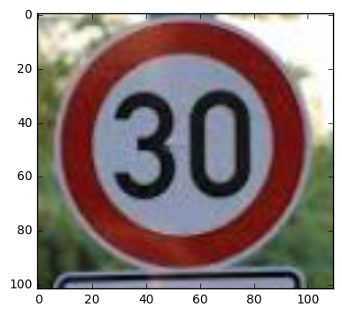

```python
plt.imshow( Image.open('./my_signs/image_0.jpg'))
```

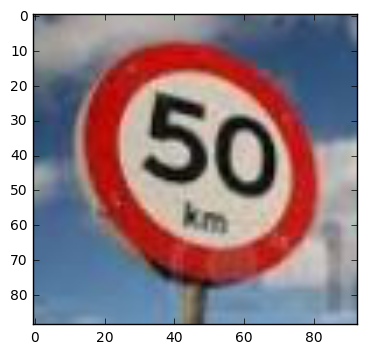

```python
plt.imshow( Image.open('./my_signs/image_1.jpg'))
```

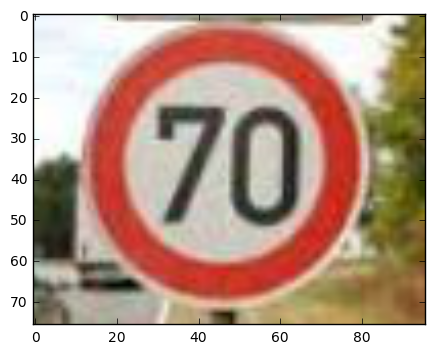

```python
plt.imshow( Image.open('./my_signs/image_2.jpg'))
```

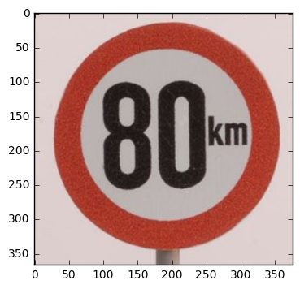

```python
plt.imshow( Image.open('./my_signs/image_3.jpg'))
```

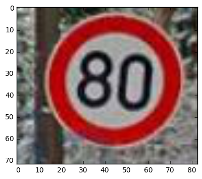

```python
plt.imshow( Image.open('./my_signs/image_4.jpg'))
```

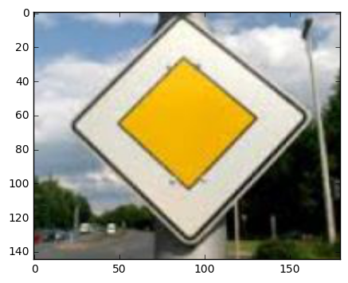

```python
plt.imshow( Image.open('./my_signs/image_5.jpg'))
```

```python
#reading in an image

def grayscale(img): # copy from lane detection program
    return cv2.cvtColor(img, cv2.COLOR_BGR2GRAY)

def readImage(str):
    img=Image.open(str)
    image=np.array(img.resize((32, 32)))
    image=grayscale(image)
    return image

def readFeatureVector(str):
    image=readImage(str)
    return np.reshape(image,1024)
```

```
25
(32, 32, 3)
```

[figure not shown]

```python
# initialising the X_myValues and y_myValues structure.
# X_myValues contain own traffic signs
# y_myValues contain the corresponding traffic sign class information
import random
import numpy as np
import matplotlib.pyplot as plt
%matplotlib inline

index = random.randint(0, len(test['features']))
image = test['features'][index]

plt.figure(figsize=(1,1))
#plt.imshow(image, cmap="gray")
plt.imshow(image)
print(test['labels'][index])
print(image.shape)
X_myValues = np.zeros((6,1024), dtype=np.float64)
y_myValues = np.ones((6), dtype=np.uint8)
y_myValues[0]=1
y_myValues[1]=2
y_myValues[2]=4
y_myValues[3]=5
y_myValues[4]=5
y_myValues[5]=12
for i in range(6):
    X_myValues[i]=np.reshape(readFeatureVector('./my_signs/image_{}.jpg'.format(i)),1024)
```

```python
with tf.Session() as sess:
    loader = tf.train.import_meta_graph('lenet-9.meta')
    loader.restore(sess, tf.train.latest_checkpoint('./'))
    test_loss, test_accuracy = evaluate(X_myValues, y_myValues)
    print("Test Loss     = {:.3f}".format(test_loss))
    print("Test Accuracy = {:.3f}".format(test_accuracy))
```

```
Test Loss     = 5.610
Test Accuracy = 0.500
```

```python
def softmax(x):
    """Compute softmax values for each sets of scores in x."""
    e_x = np.exp(x - np.max(x))
    return e_x / e_x.sum()

with tf.Session() as sess:
    loader = tf.train.import_meta_graph('lenet-9.meta')
    loader.restore(sess, tf.train.latest_checkpoint('./'))
    result =  sess.run(logits, feed_dict={x: X_myValues})
    print(result)
    print()
    for i in range (6):
        print (softmax(result[i]))
    print()
    print(sess.run(tf.nn.top_k(result, k=4)))

    print()
    print(sess.run(tf.nn.softmax(result)))

    print()
    print(sess.run(tf.nn.softmax(sess.run(tf.nn.top_k(result, k=4))[0])))

print ('done')
```

```
[[ -0.87928224  31.97571945   2.57796574 -12.8150816   -4.58293581
   17.62771988  -0.66230953   1.3641609   -4.99018526 -45.1530304
  -36.84761047 -12.40998459 -19.16361427  10.38359737 -26.4726944
  -16.02227783 -61.56178665 -21.40208817 -14.90373516 -53.43798447
  -18.14222908 -12.52358627 -44.72600555 -15.73118496 -33.52082443
    0.69727647 -18.21007919  -9.35978222   2.89458442 -13.24438381
   -9.97622299 -10.13554859 -26.7777462  -34.47898483 -40.45824432
   -9.81423569 -15.59954453 -29.98769951 -18.92648125  -3.10461497
    3.40857029 -42.1690712  -36.85944366]
 [ -2.30031157  -7.31986237   5.72242641 -16.85695839  -8.15500069
  -10.79567814 -56.60099792 -30.51898193 -22.58306503 -11.30782032
  -14.76107311   5.23161507 -21.75789642  -5.58396292 -18.28009605
  -11.01716042 -16.55870438 -17.89008331  -7.15252781  -4.31069326
  -11.06888771   8.29159355 -54.28997421   3.54721069   8.10715389
  -14.43077087   4.71022081  -2.51447725 -12.27265549  -5.25635052
  -12.16049385 -23.02587128 -35.43880844 -12.77673244  -9.37032032
   -1.56415653 -40.98594666  -3.35555172  -7.66095066  -3.78073859
   19.86246872 -48.37371826 -53.23906326]
 [ 45.0765152   32.17324829  -8.44972515  -0.96978378  48.44087601
   15.99233532 -14.11896896 -10.98677826   5.12333536 -41.6687088
  -10.02652454 -21.44243622 -27.07426643  -6.03756762   0.24907377
    7.3499136  -17.46730804 -17.02713776   0.38000295 -40.48364258
  -24.42339134 -13.49050617 -64.38012695 -40.09162521 -47.10798264
  -42.88883972   2.95408416 -35.15328979 -56.60536575 -33.5578537
  -20.61392593 -30.12902069 -28.04792595  -0.18884312 -34.94433975
    9.5716486  -53.00632477  -3.78632712 -29.0888176    4.10387802
    2.5685997  -42.08473206 -43.44400406]
 [ -4.90392447  12.65596867   8.74573708  -1.70777583 -17.35267639
   13.50115585  -7.27791691  -6.65304041 -15.05392075 -15.74358177
    1.86662352  14.98684788 -19.46714592   5.16167641 -15.98048306
  -20.71078873 -18.19107246 -19.98267937  -0.83811468 -21.54857063
  -23.26265335  22.1109333  -29.63726616   8.17295074   5.59195232
   -8.60512829 -30.84636307   0.59206676   2.28819156   9.43030548
   10.44256115   9.21646023  -2.53661132 -34.5506134  -22.97509575
  -25.40678215 -30.07468605 -14.07186317 -15.4180479  -13.34103203
    2.48678207 -30.19985962  -2.85715747]
 [-25.45027924  26.19161797  34.78238297 -14.27911091  -6.44435024
   24.02566147 -42.22806168  14.27792168  -9.46823597 -62.22052383
  -20.26236534  -1.80938959 -53.47773361 -40.40858841 -39.44885635
  -12.87301064 -42.18738556 -79.62567139   8.22486401 -39.3042717
```

[output cut: 153 more lines]

```
    0.00000000e+00   6.97034413e-32   0.00000000e+00   0.00000000e+00
    0.00000000e+00   1.60037167e-26   0.00000000e+00   0.00000000e+00
    0.00000000e+00   8.36336958e-26   8.07209460e-38   0.00000000e+00
    0.00000000e+00   3.29371751e-37   1.07277816e-37   8.67633338e-37
    1.96395851e-28   0.00000000e+00   0.00000000e+00   2.28462679e-37
    0.00000000e+00   0.00000000e+00   1.29503051e-21   0.00000000e+00
    9.23668808e-21   4.07741980e-37   1.85937713e-33]]

[[  9.99999404e-01   5.87141415e-07   4.19431156e-10   3.92142644e-13]
 [  9.99981999e-01   9.43680425e-06   7.84736494e-06   7.22852747e-07]
 [  9.66571808e-01   3.34280320e-02   8.32325497e-08   7.81650051e-15]
 [  9.98935044e-01   8.04611540e-04   1.82120333e-04   7.82164861e-05]
 [  8.87820721e-01   1.11995354e-01   1.64969417e-04   1.89121311e-05]
 [  1.00000000e+00   9.23668808e-21   1.29503051e-21   6.46915562e-24]]
done
```

### Question 6

*Choose five candidate images of traffic signs and provide them in the report. Are there any particular qualities of the image(s) that might make classification difficult? It could be helpful to plot the images in the notebook.*

**Answer:**

The network detected 4 out of 6 signs correctly (After re-running the training again only 3 out of 6 images were classified correctly; seems to depend on the random weights at the beginning). The correctly detected signs are all detected with a probability close to 1.

The model detected the 80 signs incorrectly. Instead it detected a 30 km speed limit sign. As *8 and 3 are similar* to each other and there are slightly more 30 signs are in the training set, this error can be explained.

Some of the the images are jittered, i.e. the 50, 70 and 80 km sign, and the main road image was taken from below and has a lot of background noise. A representative of all used test image classes was part of the training set so that theoretically the correct class could be detected.

```
eighty: {} 1860
thirty: {} 2220
```

[figure not shown]

```python
thirty = 0
eighty = 0
for i in range(len(train['labels'])):
    if (train['labels'][i] == 1):
        thirty = thirty + 1
    if (train['labels'][i] == 5):
        eighty = eighty + 1
print ('eighty: {}', eighty)
print ('thirty: {}', thirty)
plt.imshow(readImage('./my_signs/image_3.jpg'), cmap='gray')
```

### Question 7

*Is your model able to perform equally well on captured pictures when compared to testing on the dataset? The simplest way to do this check the accuracy of the predictions. For example, if the model predicted 1 out of 5 signs correctly, it's 20% accurate.*

**NOTE:** You could check the accuracy manually by using `signnames.csv` (same directory). This file has a mapping from the class id (0-42) to the corresponding sign name. So, you could take the class id the model outputs, lookup the name in `signnames.csv` and see if it matches the sign from the image.

**Answer:**

From the two images which were not recognized correctly, one was on 3rd position and one on the 4th position of the ordered prediction list. Strangely enough if I retrain the model with exactly the same paramaters, the resulting model is slightly different. Again it detects 4 out of the 6 images correctly but this time different images. As the only thing which changed are the initial randomly assigned weights, the whole model seems to be a little too dependent on this random values. One possibility to change this would be to set sigma to 0.

### Question 8

*Use the model's softmax probabilities to visualize the **certainty** of its predictions, [`tf.nn.top_k`](https://www.tensorflow.org/versions/r0.12/api_docs/python/nn.html#top_k) could prove helpful here. Which predictions is the model certain of? Uncertain? If the model was incorrect in its initial prediction, does the correct prediction appear in the top k? (k should be 5 at most)*

`tf.nn.top_k` will return the values and indices (class ids) of the top k predictions. So if k=3, for each sign, it'll return the 3 largest probabilities (out of a possible 43) and the correspoding class ids.

Take this numpy array as an example:

```
# (5, 6) array
a = np.array([[ 0.24879643,  0.07032244,  0.12641572,  0.34763842,  0.07893497,
         0.12789202],
       [ 0.28086119,  0.27569815,  0.08594638,  0.0178669 ,  0.18063401,
         0.15899337],
       [ 0.26076848,  0.23664738,  0.08020603,  0.07001922,  0.1134371 ,
         0.23892179],
       [ 0.11943333,  0.29198961,  0.02605103,  0.26234032,  0.1351348 ,
         0.16505091],
       [ 0.09561176,  0.34396535,  0.0643941 ,  0.16240774,  0.24206137,
         0.09155967]])
```

Running it through `sess.run(tf.nn.top_k(tf.constant(a), k=3))` produces:

```
TopKV2(values=array([[ 0.34763842,  0.24879643,  0.12789202],
       [ 0.28086119,  0.27569815,  0.18063401],
       [ 0.26076848,  0.23892179,  0.23664738],
       [ 0.29198961,  0.26234032,  0.16505091],
       [ 0.34396535,  0.24206137,  0.16240774]]), indices=array([[3, 0, 5],
       [0, 1, 4],
       [0, 5, 1],
       [1, 3, 5],
       [1, 4, 3]], dtype=int32))
```

Looking just at the first row we get `[ 0.34763842, 0.24879643, 0.12789202]`, you can confirm these are the 3 largest probabilities in `a`. You'll also notice `[3, 0, 5]` are the corresponding indices.

**Answer:**

from [37]

**Image 0** y_myValues[0]=1

output from [37]

Image 0 was classified crrectly with a rather high accuracy. The model was quite convinced about its prediction; no value was higher.

**Image 1**

output from [37]

[ -1.08160210e+00 *1.88094597e+01* **6.61503983e+00** -4.20766525e+01 6.37413883e+00 3.32592249e+00 -5.06124115e+01 -9.36838818e+00 -2.20785809e+01 -1.20761366e+01 -4.02682228e+01 -5.27104340e+01 -6.37469292e+01 -3.24300652e+01 -2.26614456e+01 -1.85807359e+00 -2.28292732e+01 -1.74982719e+01 -8.39097290e+01 -2.39673977e+01 -5.77653008e+01 -3.35736351e+01 -7.48582535e+01 -5.13354874e+01 -7.60631714e+01 -7.42924652e+01 -2.18003597e+01 -7.92951965e+01 -4.42088356e+01 -4.50305138e+01 -6.76352005e+01 -4.37660561e+01 -9.06817093e+01 -7.17418442e+01 -5.81842079e+01 -3.49277611e+01 -6.39257545e+01 -3.26425095e+01 -3.56221352e+01 *1.40277414e+01* -2.31360760e+01 -9.24605713e+01 -1.01199471e+02]

The model missclassiified this image. Still the model ranked the correct class on 3rd position.

**Image 2**

output from [37]

[ -1.76952183e+00 *4.52470284e+01* 3.51310849e+00 -2.53738346e+01 **3.95561142e+01** 5.71135283e+00 -2.91198540e+01 -3.83886032e+01 -4.57539902e+01 -5.79812965e+01 -7.55033798e+01 -2.57504005e+01 -6.94388885e+01 -5.02847366e+01 2.48126894e-01 -3.28089752e+01 -4.98323212e+01 -6.68605881e+01 -4.19506187e+01 -8.94204254e+01 -6.85542679e+01 -3.25453987e+01 -9.42722855e+01 -8.69434204e+01 -7.47697144e+01 -8.81041260e+01 -4.48805275e+01 -3.79076385e+01 -4.07920723e+01 -6.38875961e+01 -6.71459351e+01 -3.52049294e+01 -6.38321724e+01 -4.32352676e+01 -6.50552979e+01 -5.84185486e+01 -6.85210495e+01 -4.99867554e+01 -3.40911980e+01 -3.32477493e+01 -3.60621185e+01 -1.00928726e+02 -9.72369232e+01]

**Image 3**

y_myValues[3]= 5

output from [37]

[ -8.03482971e+01 2.50622082e+00 -2.62524662e+01 *2.46424694e+01* -6.63629990e+01 **3.24862099e+00** -3.04695911e+01 -8.12928772e+01 -7.41998978e+01 -9.46346817e+01 -6.10688629e+01 -4.26901293e+00 -5.47559509e+01 -6.23993568e+01 -7.48402071e+00 -4.73926735e+01 -7.58105927e+01 -9.09571304e+01 -6.31697540e+01 -7.01286774e+01 -9.95884476e+01 -1.69105701e+01 -4.07631683e+01 -2.47989674e+01 -9.80898590e+01 -3.89334679e+01 -5.89102287e+01 -5.29288673e+01 -1.20913973e+01 -4.68388605e+00 -1.80646725e+01 -2.85117970e+01 -3.00914154e+01 -7.88316879e+01 5.85624352e-02 -2.51734409e+01 -4.61550179e+01 -7.25485611e+01 -3.60384407e+01 -5.48836327e+01 -6.09880981e+01 -9.97338562e+01 -6.78237076e+01]

the model missclassified image 3. Still it was the second most likely class.

**Image 4**

y_myValues[4]= 5

output from [37]

[ 6.82277799e-01 1.41266937e+01 1.61461220e+01 4.55408764e+00 -2.54219742e+01 **1.72378044e+01** -2.10981274e+01 -3.31984663e+00 -1.80814781e+01 -2.15652256e+01 -2.66382751e+01 -4.51763725e+01 -5.84793549e+01 -5.10327148e+01 -4.25696373e+01 -2.51682892e+01 -1.80065784e+01 -5.91231117e+01 -6.64828644e+01 -1.94483547e+01 -3.38886070e+01 -1.51755390e+01 -7.10993347e+01 -1.70066624e+01 -3.80527611e+01 -5.94153862e+01 -4.39569092e+01 -5.36353569e+01 -1.90298328e+01 -2.75973186e+01 -4.57104454e+01 -1.30592680e+01 -4.90142174e+01 -3.32035027e+01 -5.02022552e+01 -3.25103264e+01 -5.88389206e+01 -3.56023636e+01 -9.73260403e+00 -1.20952253e+01 -2.31361237e+01 -7.47668457e+01 -5.14071732e+01]

teh object was classified correctly.. The model was not very certain about it as class 1 was also ranked high.

**Image 5**

y_myValues[5]= 12

output from [37]

[ -1.19517273e+02 -2.08077097e+00 -9.33617115e+00 -9.86579666e+01 -7.52601166e+01 -3.95965157e+01 -8.69132996e+01 -1.76952820e+01 -5.13018951e+01 -5.90934658e+00 -4.81104946e+00 6.12391329e+00 **9.60794067e+01** -3.50128479e+01 -6.07470284e+01 -5.17805252e+01 -4.87498055e+01 -4.03364410e+01 -8.02638474e+01 1.15154648e+00 -4.38002129e+01 8.31842273e-02 -1.06537743e+02 1.78446312e+01 -1.01086922e+02 -1.48471880e+01 -9.87766495e+01 -8.27923737e+01 -1.38754797e+01 9.74345028e-01 -2.49653244e+01 -3.06357346e+01 -8.33630600e+01 -1.06128120e+02 -5.91853180e+01 -1.96594563e+01 -9.65350342e+01 -1.35780869e+01 -4.22021179e+01 -4.05737648e+01 3.74830093e+01 -4.89612656e+01 -2.33843212e+01]]

the model classified the object correctly and was extremely confident in its decision.

As requested by the reviewe the **tf.nn.softmax** is used to get more insight into the results: In the latest run, 3 out of 6 signs were detected correctly. All correct signs were among the top four predicted signs.

[[ **9.99999404e-01** 5.87141415e-07 4.19431156e-10 3.92142644e-13] [ 9.99981999e-01 9.43680425e-06 7.84736494e-06 **7.22852747e-07**] [ **9.66571808e-01** 3.34280320e-02 8.32325497e-08 7.81650051e-15] [ 9.98935044e-01 8.04611540e-04 **1.82120333e-04** 7.82164861e-05] [ 8.87820721e-01 1.11995354e-01 1.64969417e-04 **1.89121311e-05**] [ **1.00000000e+00** 9.23668808e-21 1.29503051e-21 6.46915562e-24]]